# a4_task3_Toigo_Katelyn

Katelyn Toigo

3/6/2022

### Overview

This script uses R to conduct a text analysis of the 2021 Intergovernmental Panel on Climate Change (IPCC) Summary for Policymakers report.

First, data is wrangled to get tokens into tidy format and remove stop words, next counts for the most frequently used words in the text are visualized, then a sentiment analysis using the NRC lexicon is performed.

**Data citation:** IPCC, 2021: Summary for Policymakers. In: Climate Change 2021: The Physical Science Basis. Contribution of Working Group I to the Sixth Assessment Report of the Intergovernmental Panel on Climate Change [Masson- Delmotte, V., P. Zhai, A. Pirani, S.L. Connors, C. Péan, S. Berger, N. Caud, Y. Chen, L. Goldfarb, M.I. Gomis, M. Huang, K. Leitzell, E. Lonnoy, J.B.R. Matthews, T.K. Maycock, T. Waterfield, O. Yelekçi, R. Yu, and B. Zhou (eds.)]. Cambridge University Press. In Press. https://www.ipcc.ch/report/ar6/wg1/downloads/report/IPCC_AR6_WGI_SPM_final.pdf

### Load the 2021 IPCC Report

```r
ipcc_text <- pdf_text(here('data', 'IPCC_2021pdf.pdf'))
```

### Get the IPCC report into a dataframe and remove stop words

```r
ipcc_lines <- data.frame(ipcc_text) %>%
  mutate(page = 1:n()) %>%
  mutate(text_full = str_split(ipcc_text, pattern = '\\n')) %>%
  unnest(text_full) %>%
  mutate(text_full = str_trim(text_full))


ipcc_words <- ipcc_lines %>%
  unnest_tokens(word, text_full) %>%
  select(-ipcc_text)

# Remove stop words
#head(stop_words)

ipcc_words_clean <- ipcc_words %>%
  anti_join(stop_words, by = 'word')
```

```r
# Count
nonstop_ipcc_counts <- ipcc_words_clean %>%
  count(page, word)
```

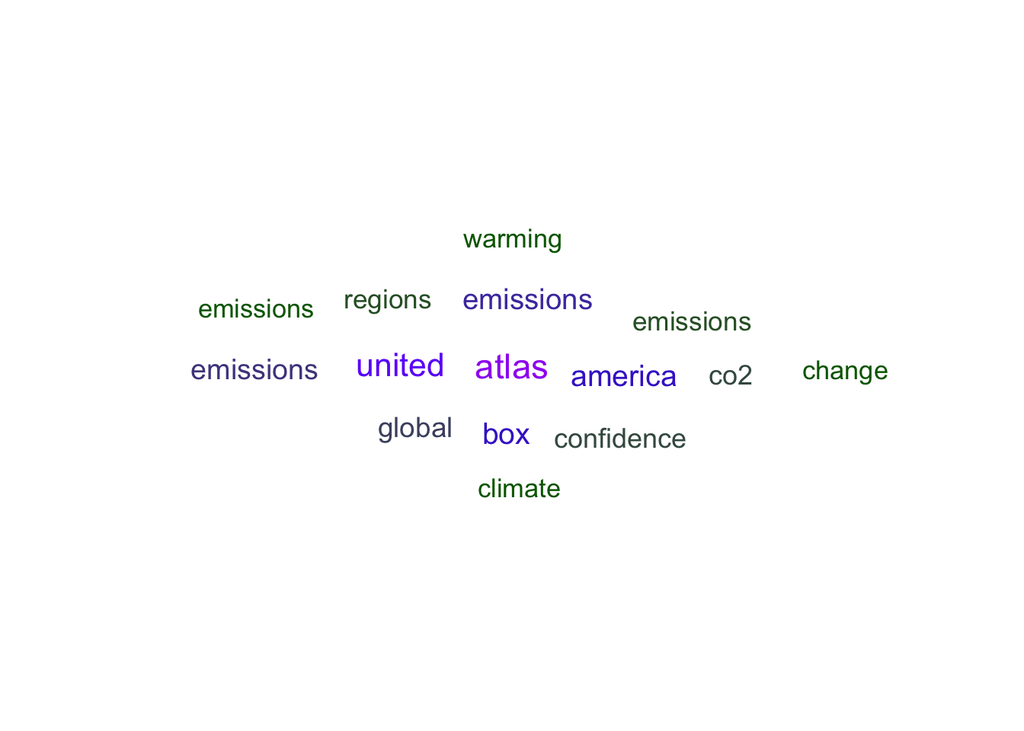

```r
top15 <- nonstop_ipcc_counts %>%
  arrange(-n) %>%
  slice(1:15)


cloud <- ggplot(data = top15,
                     aes(label = word)) +
  geom_text_wordcloud(aes(color = n, size = n), shape = "diamond") +
  scale_size_area(max_size = 6) +
  scale_color_gradientn(colors = c("darkgreen","blue","purple")) +
  theme_minimal()

cloud
```

### Sentiment analysis with NRC lexicon

NRC lexicon:https://saifmohammad.com/WebPages/NRC-Emotion-Lexicon.htm

Includes 8 emotions (anger, anticipation, disgust, fear, joy, sadness, surprise, trust).

```r
ipcc_nrc <- ipcc_words_clean %>%
  inner_join(get_sentiments("nrc"))
```

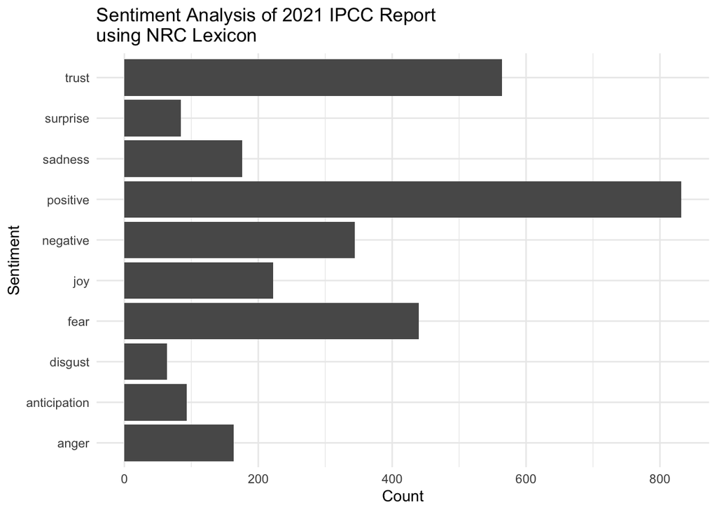

```r
# Find the count of words by page and sentiment bin:
ipcc_nrc_counts <- ipcc_nrc %>%
  count(page, sentiment)

ggplot(data = ipcc_nrc_counts, aes(x = sentiment, y = n)) +
  geom_col() +
  theme_minimal() +
  coord_flip() +
  ggtitle("Sentiment Analysis of 2021 IPCC Report\nusing NRC Lexicon") +
  labs(x = "Sentiment",
       y = "Count")
```

**Figure 2.** Graph of the results of a sentiment analysis, using the NRC lexicon, for the 2021 IPCC report.